# Data Visualization Assignment

This notebook demonstrates five different types of visualizations created with **Matplotlib**.  
The dataset is generated using **NumPy**, so the notebook can run without needing external files.

The five visualizations are:

1. Line plot
2. Bar chart
3. Histogram
4. Scatter plot
5. Custom 3D plot

Each graph includes a descriptive title, labeled axes, customized styling, and a short explanation.

```python
# Imports
import os
import numpy as np
import matplotlib.pyplot as plt
from mpl_toolkits.mplot3d import Axes3D

# Create imgs directory for exported graphs
os.makedirs("imgs", exist_ok=True)

# Reproducibility
np.random.seed(42)
```

## 1. Line Plot: Monthly Temperature Trend

This line plot shows the average monthly temperature over one year.  
A line plot is a good choice because it clearly shows how values change over time. The markers make each month easy to identify, while the dashed line helps show the overall trend.

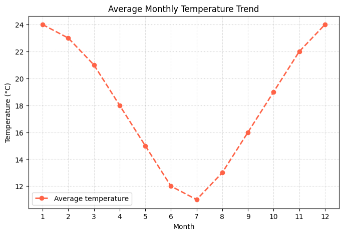

```python
# Data for line plot
months = np.arange(1, 13)
avg_temperature = np.array([24, 23, 21, 18, 15, 12, 11, 13, 16, 19, 22, 24])

plt.figure(figsize=(8, 5))
plt.plot(
    months,
    avg_temperature,
    marker="o",
    linestyle="--",
    linewidth=2,
    color="tomato",
    label="Average temperature"
)

plt.title("Average Monthly Temperature Trend")
plt.xlabel("Month")
plt.ylabel("Temperature (°C)")
plt.xticks(months)
plt.grid(True, linestyle=":", alpha=0.7)
plt.legend()

plt.savefig("imgs/line_plot.png", dpi=300, bbox_inches="tight")
plt.show()
```

## 2. Bar Chart: Sales by Product Category

This bar chart compares total sales across five product categories.  
A bar chart is appropriate because it makes it easy to compare separate groups. The different bar colors help visually separate each category.

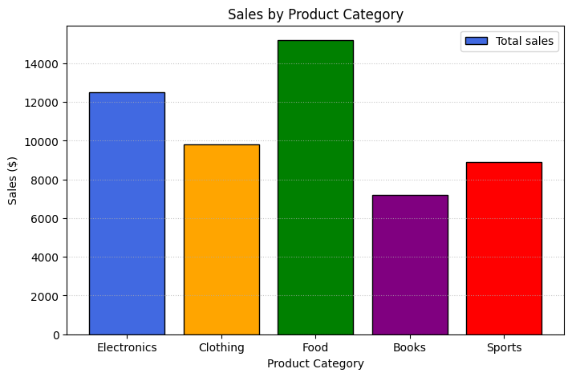

```python
# Data for bar chart
categories = ["Electronics", "Clothing", "Food", "Books", "Sports"]
sales = [12500, 9800, 15200, 7200, 8900]

plt.figure(figsize=(8, 5))
plt.bar(
    categories,
    sales,
    color=["royalblue", "orange", "green", "purple", "red"],
    edgecolor="black",
    label="Total sales"
)

plt.title("Sales by Product Category")
plt.xlabel("Product Category")
plt.ylabel("Sales ($)")
plt.grid(axis="y", linestyle=":", alpha=0.7)
plt.legend()

plt.savefig("imgs/bar_chart.png", dpi=300, bbox_inches="tight")
plt.show()
```

## 3. Histogram: Distribution of Exam Scores

This histogram shows how exam scores are distributed among a group of students.  
A histogram is useful because it groups continuous numerical data into ranges. It helps identify whether most students scored low, average, or high.

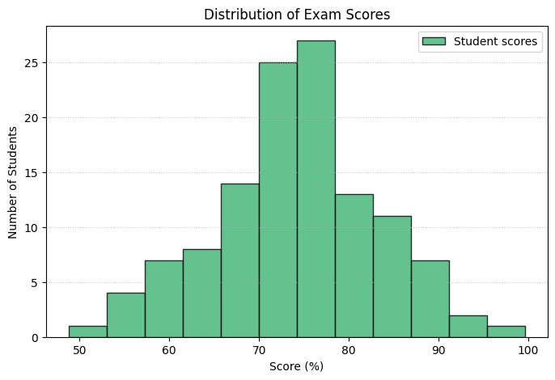

```python
# Data for histogram
exam_scores = np.random.normal(loc=75, scale=10, size=120)
exam_scores = np.clip(exam_scores, 0, 100)

plt.figure(figsize=(8, 5))
plt.hist(
    exam_scores,
    bins=12,
    color="mediumseagreen",
    edgecolor="black",
    alpha=0.8,
    label="Student scores"
)

plt.title("Distribution of Exam Scores")
plt.xlabel("Score (%)")
plt.ylabel("Number of Students")
plt.grid(axis="y", linestyle=":", alpha=0.7)
plt.legend()

plt.savefig("imgs/histogram.png", dpi=300, bbox_inches="tight")
plt.show()
```

## 4. Scatter Plot: Study Hours vs Exam Score

This scatter plot shows the relationship between hours studied and exam scores.  
A scatter plot is the best option because it displays the connection between two numerical variables. The upward pattern suggests that students who study more hours generally achieve higher scores.

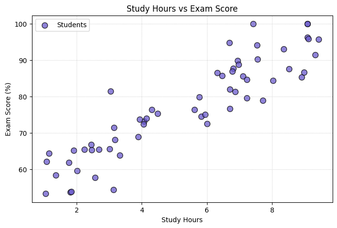

```python
# Data for scatter plot
study_hours = np.random.uniform(1, 10, 60)
scores = 50 + study_hours * 5 + np.random.normal(0, 6, 60)
scores = np.clip(scores, 0, 100)

plt.figure(figsize=(8, 5))
plt.scatter(
    study_hours,
    scores,
    s=70,
    color="slateblue",
    edgecolor="black",
    alpha=0.75,
    label="Students"
)

plt.title("Study Hours vs Exam Score")
plt.xlabel("Study Hours")
plt.ylabel("Exam Score (%)")
plt.grid(True, linestyle=":", alpha=0.7)
plt.legend()

plt.savefig("imgs/scatter_plot.png", dpi=300, bbox_inches="tight")
plt.show()
```

## 5. Custom 3D Plot: Mathematical Surface

This custom 3D surface plot shows the shape of the function `z = sin(sqrt(x² + y²))`.  
A 3D plot is useful because it allows us to visualize how a value changes across two input variables. The surface style makes the peaks and valleys of the function easier to understand.

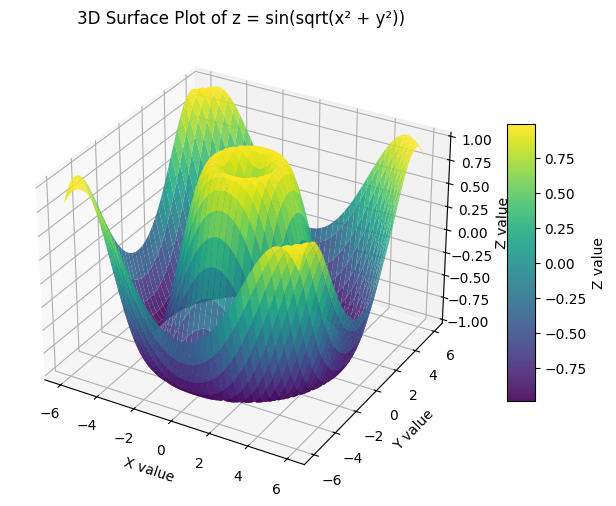

```python
# Data for custom 3D plot
x = np.linspace(-6, 6, 80)
y = np.linspace(-6, 6, 80)
X, Y = np.meshgrid(x, y)
Z = np.sin(np.sqrt(X**2 + Y**2))

fig = plt.figure(figsize=(9, 6))
ax = fig.add_subplot(111, projection="3d")

surface = ax.plot_surface(
    X,
    Y,
    Z,
    cmap="viridis",
    edgecolor="none",
    alpha=0.9
)

ax.set_title("3D Surface Plot of z = sin(sqrt(x² + y²))")
ax.set_xlabel("X value")
ax.set_ylabel("Y value")
ax.set_zlabel("Z value")
fig.colorbar(surface, shrink=0.6, aspect=10, label="Z value")

plt.savefig("imgs/custom_plot.png", dpi=300, bbox_inches="tight")
plt.show()
```

## Conclusion

This notebook includes five different Matplotlib visualizations using generated data. Each graph was saved as a PNG file inside the `imgs/` folder using `dpi=300` and `bbox_inches='tight'`. The visualizations demonstrate different ways to represent trends, comparisons, distributions, relationships, and 3D mathematical data.